# EDA

Anni Hong

9/15/2020

## Basic Info:

### Individual dataset

- The individual dataset contains 370 observations, and 10 variables :  
  ID Participant ID number team.id ID number of the team this participant belonged to Age Age, in years Gender Gender (Male or Female) Ethnicity Ethnicity of the participant Cortisol Participant's cortisol levels, nMol/L Testosterone Participant's testosterone levels, pg/mL log.cortisol Natural logarithm of the participant's cortisol level log.testosterone Natural logarithm of the participant's testosterone level Country Country of citizenship of the participant
- 18 rows contain at least one missing value in one of the columns

### Team dataset

- The team dataset contains 74 teams and 14 variables:  
  team.id Team ID number team.size Number of people on the team final.performance The team's final performance score time.of.day The time of day the team's hormone sample was collected (hh.mm) females Number of females in the group final.cash Total cash earned by the team final.contracts Total number of contracts won by the team final.reorders Total number of reorders won by the team final.rank Team's final rank at the end of the project, relative to other teams in their class section interim.performance Same as above, but measured at Day 5 of the study (missing for some teams) interim.cash  
  interim.contracts  
  interim.reorders  
  interim.rank
- 22 teams have no interim.rank, interim.reorders, interim.contracts, interim.cash,and interim.performance

```r
#factorize certain variables and create diversity score for each group
indi_dat <- indi_dat %>%
  mutate_if(sapply(indi_dat, is.character), as.factor) %>%
  group_by(team.id) %>%
  mutate(diversity_score = n_distinct(Gender, Ethnicity, Country))

#intermidiate step of calculating aggregated statistics by group
agg_indi_dat <- indi_dat %>%
  group_by(team.id) %>%
  summarise(mean_testo = mean(Testosterone), mean_log_testo = mean(log.testosterone), sd_testo = sd(Testosterone), sd_log_testo = sd(log.testosterone), mean_cortisol = mean(Cortisol), mean_log_cortisol = mean(log.cortisol), sd_cortisol = sd(Cortisol), sd_log_cortisol = sd(log.cortisol), diversity_score = n_distinct(Gender, Ethnicity, Country), team_size = n())
#combing the info from the individual dataset to the team dataset, average/sd cortisol and testosterone/sd levels are calculated
combo_dat <- team_dat %>%
  inner_join(agg_indi_dat, by = "team.id")
```

## Understanding the variables

# Typical amount of diversity present:

```r
diversity_vars <- indi_dat %>% select(Gender, Ethnicity, Country)
summary(diversity_vars[,-1])
```

```
##     Gender               Ethnicity        Country
##  Female:133   Asian           : 61   USA      :213
##  Male  :237   Black           : 17   China    : 19
##               Hispanic        : 40   India    : 16
##               Other           :  9   Korea    : 10
##               South Asian     : 35   Argentina:  9
##               South East Asian:  5   Canada   :  8
##               White           :203   (Other)  : 95
```

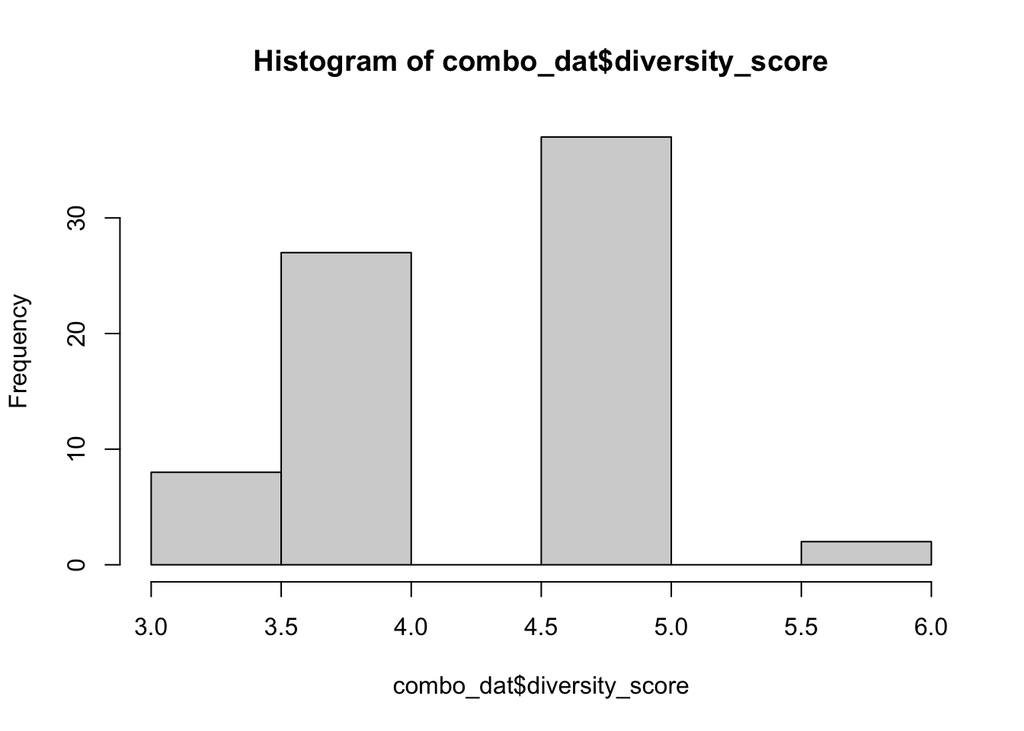

```r
hist(combo_dat$diversity_score)
```

This dataset has a lot more men than women and mostly white Americans. There is a adequate amount of variability in the diversity scores.

### testostreone vs log testostrone

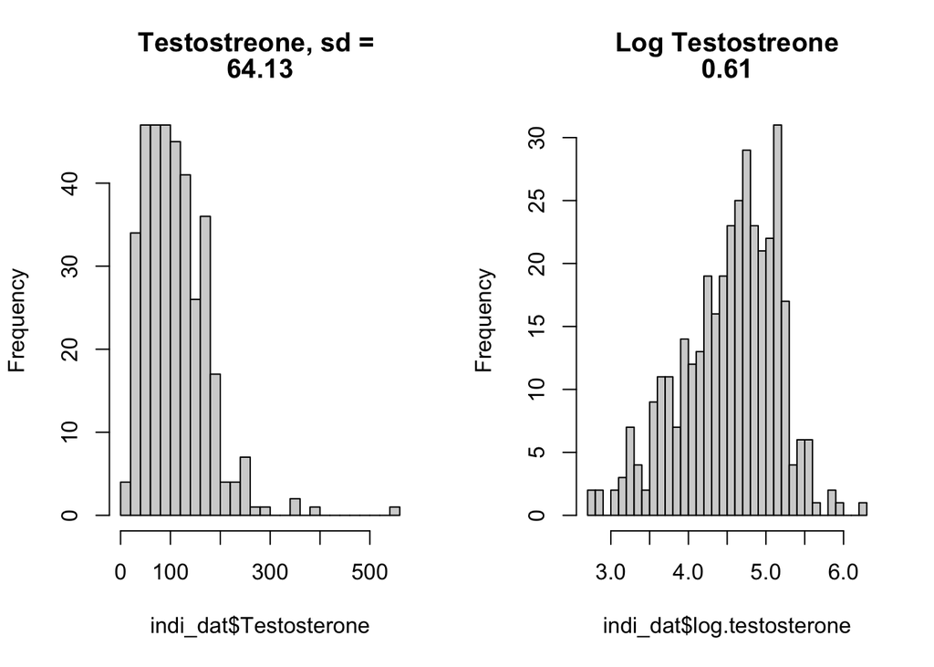

```r
par(mfrow=c(1,2))
sd_testo = round(sd(indi_dat$Testosterone, na.rm = T),2)
sd_log_testo = round(sd(indi_dat$log.testosterone, na.rm = T),2)
hist(indi_dat$Testosterone, breaks = 30, main = c("Testostreone, sd = ",sd_testo))
hist(indi_dat$log.testosterone, breaks = 30, main = c("Log Testostreone", sd_log_testo))
```

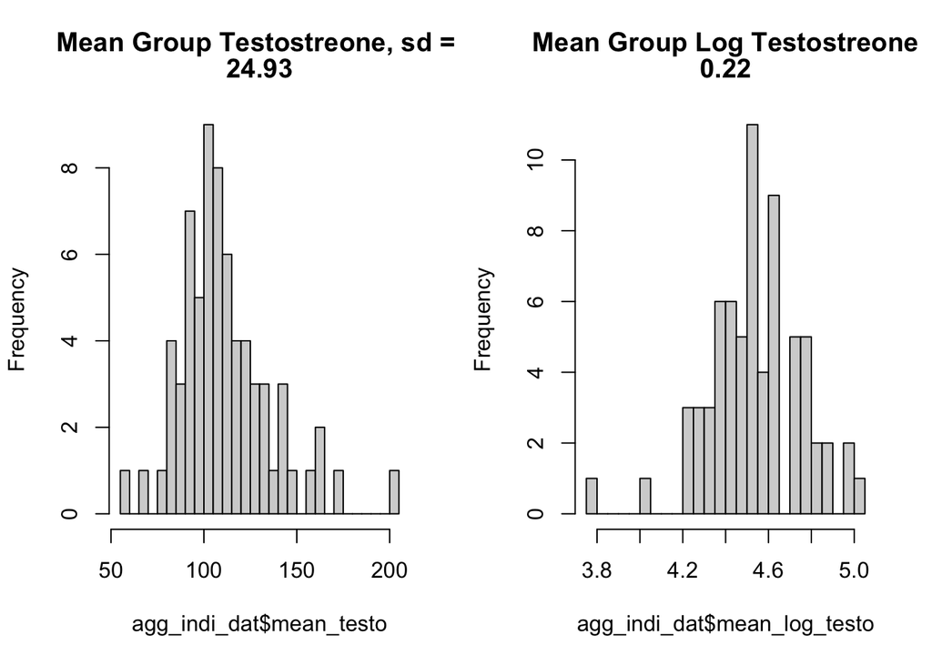

```r
par(mfrow=c(1,2))
sd_testo = round(sd(agg_indi_dat$mean_testo, na.rm = T),2)
sd_log_testo = round(sd(agg_indi_dat$mean_log_testo, na.rm = T),2)
hist(agg_indi_dat$mean_testo, breaks = 30, main = c("Mean Group Testostreone, sd = ",sd_testo))
hist(agg_indi_dat$mean_log_testo, breaks = 30, main = c("Mean Group Log Testostreone", sd_log_testo))
```

The above plots shows the histogram of the testostrone level compared to the log of the testostrone level, for overall as well as group mean. The log transformation helps with lessen the impact of outliers on our analysis. We don't want to let the group that contain the individual with really high testostrone level impact our analysis disproportionally since mean is very sensitive to outliers. The standard deviation is drastically reduced in the log transformed variable in both cases and the histogram approximate a normal distribution.

### testostrone, cortisol by gender

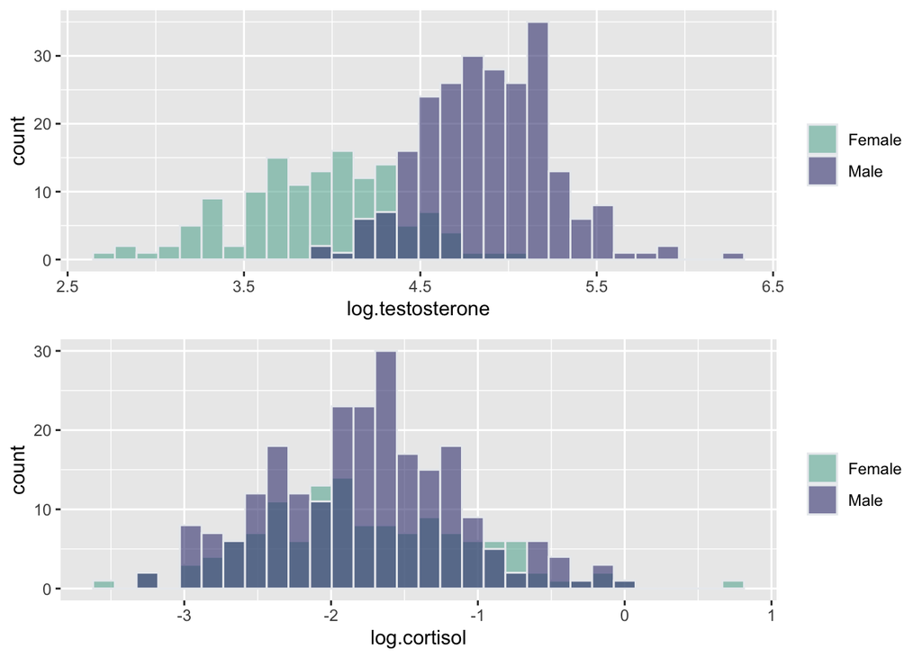

```r
testo <- indi_dat %>%
  ggplot( aes(x=log.testosterone, fill=Gender)) +
    geom_histogram( color="#e9ecef", alpha=0.6, position = 'identity') +
    scale_fill_manual(values=c("#69b3a2", "#404080")) +
    labs(fill="")

cortisol <- indi_dat %>%
  ggplot( aes(x=log.cortisol, fill=Gender)) +
    geom_histogram( color="#e9ecef", alpha=0.6, position = 'identity') +
    scale_fill_manual(values=c("#69b3a2", "#404080")) +
    labs(fill="")

grid.arrange(testo, cortisol)
```

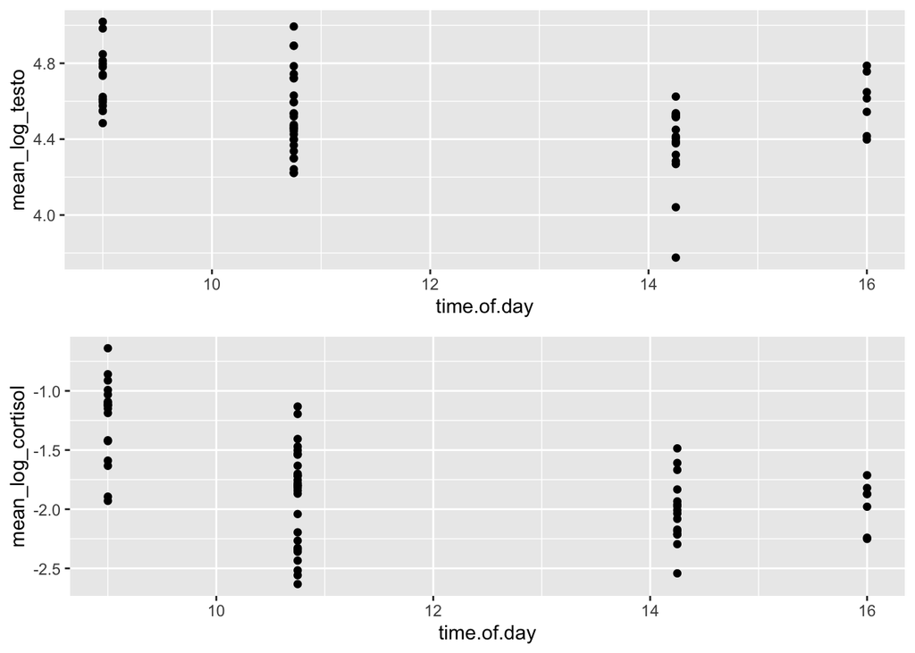

```r
testo <- combo_dat %>%
  ggplot(aes(x=time.of.day, y=mean_log_testo)) +
    geom_point()

cortisol <- combo_dat %>%
  ggplot(aes(x=time.of.day, y=mean_log_cortisol)) +
    geom_point()

grid.arrange(testo, cortisol)
```

Time of the day could also be a confounder since the testostrone and cortisol level could change base on what time of the day you measure it.

## relationships between a subset of variables

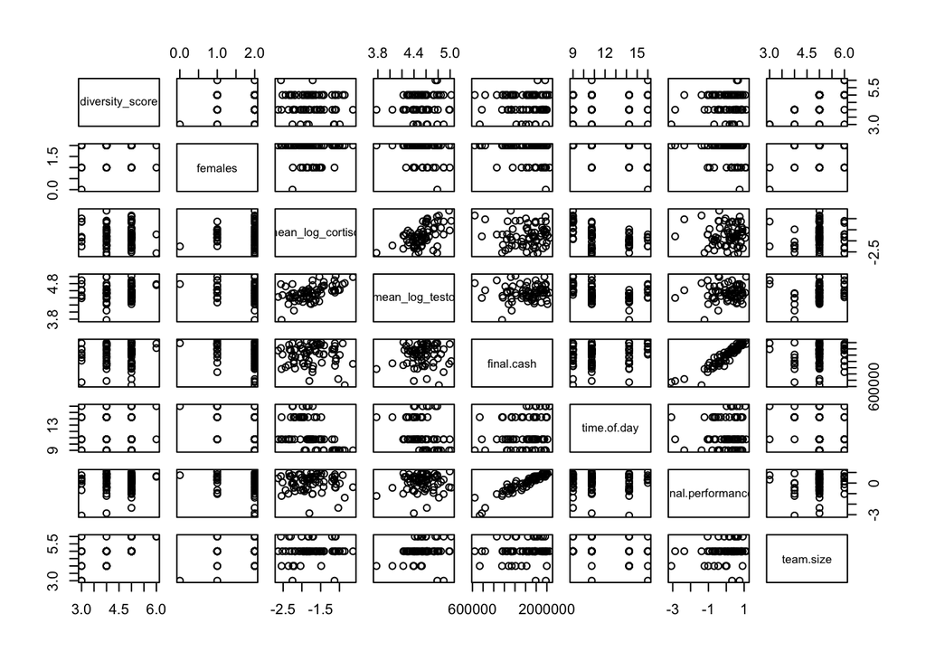

```r
combo_dat_subset <- combo_dat %>% select(diversity_score,females, mean_log_cortisol, mean_log_testo,  final.cash, time.of.day, final.performance, team.size)
pairs(combo_dat_subset) # not including team id
```